# NYC TAXI DATA

## Data Analysis of NYC Taxi Trip Data

Group 17 : Deepika Chowdary Battula, Laksmi Shivani Reddy, Lakshmi Pranita Kolaganti, Rohini Bandi

### OBJECTIVE

The objective of the project is to identify the trip duration to travel from one place to another in New York City and plotting the various contributing factors versus trip duration.

### PROBLEM STATEMENT

To build a machine learning model to predict time duration from NYC taxi trip data set.

##### Importing Libraries

```python
import numpy as np
import pandas as pd
import seaborn as sns
import matplotlib.pyplot as plt
import datetime as dt
```

```python
from sklearn.linear_model import LinearRegression
from sklearn.ensemble import RandomForestRegressor
from sklearn import metrics
from sklearn.model_selection import train_test_split, GridSearchCV
```

```python
from haversine import haversine
import statsmodels.formula.api as sm
from sklearn.model_selection import ShuffleSplit
import warnings; warnings.simplefilter('ignore')
```

##### Data Fields:

1. id - a unique identifier for each trip
2. vendor_id - a code indicating the provider associated with the trip record
3. pickup_datetime - date and time when the meter was engaged
4. dropoff_datetime - date and time when the meter was disengaged
5. passenger_count - the number of passengers in the vehicle (driver entered value)
6. pickup_longitude - the longitude where the meter was engaged
7. pickup_latitude - the latitude where the meter was engaged
8. dropoff_longitude - the longitude where the meter was disengaged
9. dropoff_latitude - the latitude where the meter was disengaged
10. store_and_fwd_flag - This flag indicates whether the trip record was held in vehicle memory before sending to the vendor because the vehicle did not have a connection to the server - Y=store and forward; N=not a store and forward trip.

```python
#import the data from a csv file.
data = pd.read_csv('C:/Users/12054/Downloads/train123/train123.csv')
```

```python
data.head()
```

|  | id | vendor_id | pickup_datetime | dropoff_datetime | passenger_count | pickup_longitude | pickup_latitude | dropoff_longitude | dropoff_latitude | store_and_fwd_flag | trip_duration |
| --- | --- | --- | --- | --- | --- | --- | --- | --- | --- | --- | --- |
| 0 | id2875421 | 2.0 | 3/14/2016 17:24 | 3/14/2016 17:32 | 1.0 | -73.982155 | 40.767937 | -73.964630 | 40.765602 | N | 455.0 |
| 1 | id2377394 | 1.0 | 6/12/2016 0:43 | 6/12/2016 0:54 | 1.0 | -73.980415 | 40.738564 | -73.999481 | 40.731152 | N | 663.0 |
| 2 | id3858529 | 2.0 | 1/19/2016 11:35 | 1/19/2016 12:10 | 1.0 | -73.979027 | 40.763939 | -74.005333 | 40.710087 | N | 2124.0 |
| 3 | id3504673 | 2.0 | 4/6/2016 19:32 | 4/6/2016 19:39 | 1.0 | -74.010040 | 40.719971 | -74.012268 | 40.706718 | N | 429.0 |
| 4 | id2181028 | 2.0 | 3/26/2016 13:30 | 3/26/2016 13:38 | 1.0 | -73.973053 | 40.793209 | -73.972923 | 40.782520 | N | 435.0 |

```python
#Check shape of dataset
data.shape
```

```
(1048575, 11)
```

```python
#Check count of unique id's in the dataset
print("There are %d unique id's in Training dataset, which is equal to the number of records"%(data.id.nunique()))
```

```
There are 1048570 unique id's in Training dataset, which is equal to the number of records
```

```python
#Check for NaN values
data.isnull().sum()
```

```
id                    5
vendor_id             5
pickup_datetime       5
dropoff_datetime      5
passenger_count       5
pickup_longitude      5
pickup_latitude       5
dropoff_longitude     5
dropoff_latitude      5
store_and_fwd_flag    5
trip_duration         5
dtype: int64
```

```python
#Convert timestamp to datetime format to fetch the other details as listed below
data['pickup_datetime'] = pd.to_datetime(data['pickup_datetime'])
data['dropoff_datetime'] = pd.to_datetime(data['dropoff_datetime'])
```

```python
#Calculate and assign new columns to the dataframe such as weekday,
#month and pickup_hour which will help us to gain more insights from the data.
data['weekday'] = data.pickup_datetime.dt.weekday_name
data['month'] = data.pickup_datetime.dt.month
data['weekday_num'] = data.pickup_datetime.dt.weekday
data['pickup_hour'] = data.pickup_datetime.dt.hour
```

```python
#calc_distance is a function to calculate distance between pickup and dropoff coordinates using Haversine formula.
def calc_distance(df):
    pickup = (df['pickup_latitude'], df['pickup_longitude'])
    drop = (df['dropoff_latitude'], df['dropoff_longitude'])
    return haversine(pickup, drop)
```

```python
#Calculate distance and assign new column to the dataframe.
data['distance'] = data.apply(lambda x: calc_distance(x), axis = 1)
```

```python
#Calculate Speed in km/h for further insights
data['speed'] = (data.distance/(data.trip_duration/3600))
```

```python
#Check the type of each variable
data.dtypes.reset_index()
```

|  | index | 0 |
| --- | --- | --- |
| 0 | id | object |
| 1 | vendor_id | float64 |
| 2 | pickup_datetime | datetime64[ns] |
| 3 | dropoff_datetime | datetime64[ns] |
| 4 | passenger_count | float64 |
| 5 | pickup_longitude | float64 |
| 6 | pickup_latitude | float64 |
| 7 | dropoff_longitude | float64 |
| 8 | dropoff_latitude | float64 |
| 9 | store_and_fwd_flag | object |
| 10 | trip_duration | float64 |
| 11 | weekday | object |
| 12 | month | float64 |
| 13 | weekday_num | float64 |
| 14 | pickup_hour | float64 |
| 15 | distance | float64 |
| 16 | speed | float64 |

```python
#Dummify all the categorical features like "store_and_fwd_flag, vendor_id, month, weekday_num, pickup_hour, passenger_count" except the label i.e. "trip_duration"

dummy = pd.get_dummies(data.store_and_fwd_flag, prefix='flag')
dummy.drop(dummy.columns[0], axis=1, inplace=True) #avoid dummy trap
data = pd.concat([data,dummy], axis = 1)

dummy = pd.get_dummies(data.vendor_id, prefix='vendor_id')
dummy.drop(dummy.columns[0], axis=1, inplace=True) #avoid dummy trap
data = pd.concat([data,dummy], axis = 1)

dummy = pd.get_dummies(data.month, prefix='month')
dummy.drop(dummy.columns[0], axis=1, inplace=True) #avoid dummy trap
data = pd.concat([data,dummy], axis = 1)

dummy = pd.get_dummies(data.weekday_num, prefix='weekday_num')
dummy.drop(dummy.columns[0], axis=1, inplace=True) #avoid dummy trap
data = pd.concat([data,dummy], axis = 1)

dummy = pd.get_dummies(data.pickup_hour, prefix='pickup_hour')
dummy.drop(dummy.columns[0], axis=1, inplace=True) #avoid dummy trap
data = pd.concat([data,dummy], axis = 1)

dummy = pd.get_dummies(data.passenger_count, prefix='passenger_count')
dummy.drop(dummy.columns[0], axis=1, inplace=True) #avoid dummy trap
data = pd.concat([data,dummy], axis = 1)
```

```python
data.head()
```

|  | id | vendor_id | pickup_datetime | dropoff_datetime | passenger_count | pickup_longitude | pickup_latitude | dropoff_longitude | dropoff_latitude | store_and_fwd_flag | ... | pickup_hour_23.0 | passenger_count_1.0 | passenger_count_2.0 | passenger_count_3.0 | passenger_count_4.0 | passenger_count_5.0 | passenger_count_6.0 | passenger_count_7.0 | passenger_count_8.0 | passenger_count_9.0 |
| --- | --- | --- | --- | --- | --- | --- | --- | --- | --- | --- | --- | --- | --- | --- | --- | --- | --- | --- | --- | --- | --- |
| 0 | id2875421 | 2.0 | 2016-03-14 17:24:00 | 2016-03-14 17:32:00 | 1.0 | -73.982155 | 40.767937 | -73.964630 | 40.765602 | N | ... | 0 | 1 | 0 | 0 | 0 | 0 | 0 | 0 | 0 | 0 |
| 1 | id2377394 | 1.0 | 2016-06-12 00:43:00 | 2016-06-12 00:54:00 | 1.0 | -73.980415 | 40.738564 | -73.999481 | 40.731152 | N | ... | 0 | 1 | 0 | 0 | 0 | 0 | 0 | 0 | 0 | 0 |
| 2 | id3858529 | 2.0 | 2016-01-19 11:35:00 | 2016-01-19 12:10:00 | 1.0 | -73.979027 | 40.763939 | -74.005333 | 40.710087 | N | ... | 0 | 1 | 0 | 0 | 0 | 0 | 0 | 0 | 0 | 0 |
| 3 | id3504673 | 2.0 | 2016-04-06 19:32:00 | 2016-04-06 19:39:00 | 1.0 | -74.010040 | 40.719971 | -74.012268 | 40.706718 | N | ... | 0 | 1 | 0 | 0 | 0 | 0 | 0 | 0 | 0 | 0 |
| 4 | id2181028 | 2.0 | 2016-03-26 13:30:00 | 2016-03-26 13:38:00 | 1.0 | -73.973053 | 40.793209 | -73.972923 | 40.782520 | N | ... | 0 | 1 | 0 | 0 | 0 | 0 | 0 | 0 | 0 | 0 |

5 rows × 62 columns

Our dataset is now complete for analysis before we train our model.

##### Passengers

Passenger limit: Maximum : 4 Minivans : 5 A child under the age of 7 is allowed to sit on passenger's lap. A maximum of 6 passengers can board the taxi. i.e 5 adult + 1 minor.

```python
pd.options.display.float_format = '{:.2f}'.format #To suppres scientific notation.
data.passenger_count.value_counts()
```

```
1.00    743127
2.00    151078
5.00     56252
3.00     43033
6.00     34700
4.00     20336
0.00        39
7.00         3
8.00         1
9.00         1
Name: passenger_count, dtype: int64
```

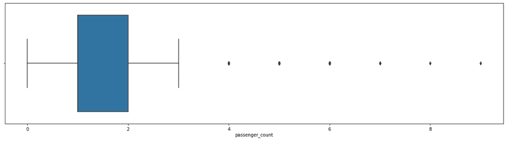

```python
plt.figure(figsize = (20,5))
sns.boxplot(data.passenger_count)
plt.show()
```

##### OBSERVATIONS:

We can observe that some trips are with 0 passengers and maximum number of the trips are with either 1 or 2 passengers.

```python
data.passenger_count.describe()
```

```
count   1048570.00
mean          1.66
std           1.31
min           0.00
25%           1.00
50%           1.00
75%           2.00
max           9.00
Name: passenger_count, dtype: float64
```

We would replace the 0 passenger count with 1 as the mean, median and mode are all approximated equal to 1.

```python
data['passenger_count'] = data.passenger_count.map(lambda x: 1 if x == 0 else x)
```

We limited the passenger count to 6 or less as count greater than 6 look odd to be occupied in a taxi.

```python
data = data[data.passenger_count <= 6]
```

```python
data.passenger_count.value_counts()
```

```
1.00    743166
2.00    151078
5.00     56252
3.00     43033
6.00     34700
4.00     20336
Name: passenger_count, dtype: int64
```

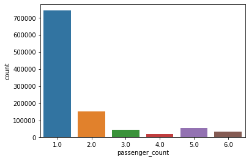

```python
sns.countplot(data.passenger_count)
plt.show()
```

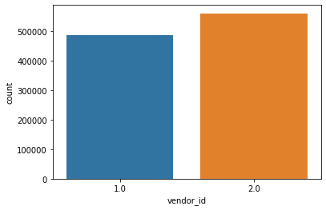

```python
sns.countplot(data.vendor_id)
plt.show()
```

In the above graph, Vendor-id was plotted against count (population). We can see that vendor 2 is more famous among people as compared to vendor 1.

##### DISTANCE

Distribution of distance across different types of rides.

```python
print(data.distance.describe())
```

```
count   1048565.00
mean          3.44
std           4.38
min           0.00
25%           1.23
50%           2.09
75%           3.88
max        1240.91
Name: distance, dtype: float64
```

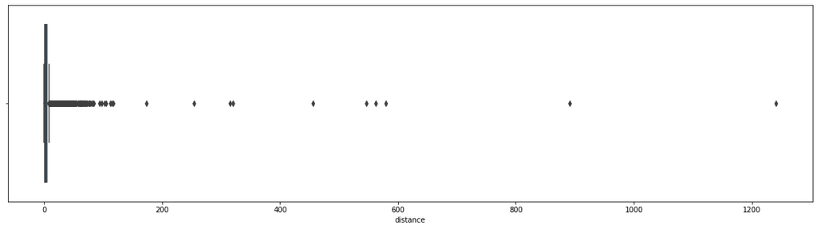

```python
plt.figure(figsize = (20,5))
sns.boxplot(data.distance)
plt.show()
```

##### OBSERVATIONS:

Mean distance travelled is approximately 3.5 kms.

```python
print("There are {} trip records with 0 km distance".format(data.distance[data.distance == 0 ].count()))
```

```
There are 4284 trip records with 0 km distance
```

```python
data[data.distance == 0 ].head()
```

|  | id | vendor_id | pickup_datetime | dropoff_datetime | passenger_count | pickup_longitude | pickup_latitude | dropoff_longitude | dropoff_latitude | store_and_fwd_flag | ... | pickup_hour_23.0 | passenger_count_1.0 | passenger_count_2.0 | passenger_count_3.0 | passenger_count_4.0 | passenger_count_5.0 | passenger_count_6.0 | passenger_count_7.0 | passenger_count_8.0 | passenger_count_9.0 |
| --- | --- | --- | --- | --- | --- | --- | --- | --- | --- | --- | --- | --- | --- | --- | --- | --- | --- | --- | --- | --- | --- |
| 246 | id3487442 | 2.00 | 2016-02-29 18:39:00 | 2016-02-29 18:42:00 | 1.00 | -73.98 | 40.77 | -73.98 | 40.77 | N | ... | 0 | 1 | 0 | 0 | 0 | 0 | 0 | 0 | 0 | 0 |
| 291 | id0924324 | 2.00 | 2016-05-10 18:07:00 | 2016-05-10 18:26:00 | 2.00 | -73.96 | 40.78 | -73.96 | 40.78 | N | ... | 0 | 0 | 1 | 0 | 0 | 0 | 0 | 0 | 0 | 0 |
| 407 | id1145809 | 2.00 | 2016-05-16 23:15:00 | 2016-05-16 23:31:00 | 6.00 | -73.81 | 40.69 | -73.81 | 40.69 | N | ... | 1 | 0 | 0 | 0 | 0 | 0 | 1 | 0 | 0 | 0 |
| 702 | id3499387 | 1.00 | 2016-01-25 19:45:00 | 2016-01-25 19:54:00 | 1.00 | -73.79 | 40.65 | -73.79 | 40.65 | N | ... | 0 | 1 | 0 | 0 | 0 | 0 | 0 | 0 | 0 | 0 |
| 1620 | id0753277 | 1.00 | 2016-01-27 22:29:00 | 2016-01-27 22:29:00 | 1.00 | -74.21 | 40.82 | -74.21 | 40.82 | N | ... | 0 | 1 | 0 | 0 | 0 | 0 | 0 | 0 | 0 | 0 |

5 rows × 62 columns

Our main goal is to find the distance travelled.

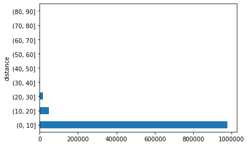

```python
data.distance.groupby(pd.cut(data.distance, np.arange(0,100,10))).count().plot(kind='barh')
plt.show()
```

From the above observation it is shown that most rides are completed between 1-10 kms. Some rides with distance between 10-30 kms. Other non- visible slabs have travlled very less as compared to these slabs. Few trips which have more distance travlled are considered them as outliers and removed before plotting.

##### TRIP DURATION

OBSERVATIONS:

```python
data.trip_duration.describe()
```

```
count   1048565.00
mean        962.15
std        5853.03
min           1.00
25%         397.00
50%         662.00
75%        1075.00
max     3526282.00
Name: trip_duration, dtype: float64
```

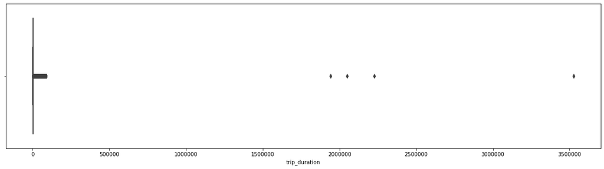

```python
plt.figure(figsize = (20,5))
sns.boxplot(data.trip_duration)
plt.show()
```

```python
data.trip_duration.groupby(pd.cut(data.trip_duration, np.arange(1,max(data.trip_duration),3600))).count()
```

```
trip_duration
(1.0, 3601.0]             1039702
(3601.0, 7201.0]             7213
(7201.0, 10801.0]             106
(10801.0, 14401.0]             26
(14401.0, 18001.0]              4
(18001.0, 21601.0]              9
(21601.0, 25201.0]              7
(25201.0, 28801.0]             11
(28801.0, 32401.0]             10
(32401.0, 36001.0]              5
(36001.0, 39601.0]              5
(39601.0, 43201.0]              3
(43201.0, 46801.0]              8
(46801.0, 50401.0]              3
(50401.0, 54001.0]              5
(54001.0, 57601.0]              4
(57601.0, 61201.0]              9
(61201.0, 64801.0]              5
(64801.0, 68401.0]              6
(68401.0, 72001.0]              2
(72001.0, 75601.0]              6
(75601.0, 79201.0]             12
(79201.0, 82801.0]             43
(82801.0, 86401.0]           1333
(86401.0, 90001.0]              0
(90001.0, 93601.0]              0
(93601.0, 97201.0]              0
(97201.0, 100801.0]             0
(100801.0, 104401.0]            0
(104401.0, 108001.0]            0
                           ...
(3416401.0, 3420001.0]          0
(3420001.0, 3423601.0]          0
(3423601.0, 3427201.0]          0
(3427201.0, 3430801.0]          0
(3430801.0, 3434401.0]          0
(3434401.0, 3438001.0]          0
(3438001.0, 3441601.0]          0
(3441601.0, 3445201.0]          0
```

[output cut: 8 more lines]

```
(3474001.0, 3477601.0]          0
(3477601.0, 3481201.0]          0
(3481201.0, 3484801.0]          0
(3484801.0, 3488401.0]          0
(3488401.0, 3492001.0]          0
(3492001.0, 3495601.0]          0
(3495601.0, 3499201.0]          0
(3499201.0, 3502801.0]          0
(3502801.0, 3506401.0]          0
(3506401.0, 3510001.0]          0
(3510001.0, 3513601.0]          0
(3513601.0, 3517201.0]          0
(3517201.0, 3520801.0]          0
(3520801.0, 3524401.0]          0
Name: trip_duration, Length: 979, dtype: int64
```

##### OBSERVATION:

1. Major chunk of trips are completed within an interval of 1 hour with some good numbers of trips duration going above 1 hour.
2. There are some trips with more than 24 hours of travel duration i.e. 86400 seconds.

```python
data[data.trip_duration > 86400]
```

|  | id | vendor_id | pickup_datetime | dropoff_datetime | passenger_count | pickup_longitude | pickup_latitude | dropoff_longitude | dropoff_latitude | store_and_fwd_flag | ... | pickup_hour_23.0 | passenger_count_1.0 | passenger_count_2.0 | passenger_count_3.0 | passenger_count_4.0 | passenger_count_5.0 | passenger_count_6.0 | passenger_count_7.0 | passenger_count_8.0 | passenger_count_9.0 |
| --- | --- | --- | --- | --- | --- | --- | --- | --- | --- | --- | --- | --- | --- | --- | --- | --- | --- | --- | --- | --- | --- |
| 355003 | id1864733 | 1.00 | 2016-01-05 00:19:00 | 2016-01-27 11:08:00 | 1.00 | -73.79 | 40.64 | -73.96 | 40.77 | N | ... | 0 | 1 | 0 | 0 | 0 | 0 | 0 | 0 | 0 | 0 |
| 680594 | id0369307 | 1.00 | 2016-02-13 22:38:00 | 2016-03-08 15:57:00 | 2.00 | -73.92 | 40.74 | -73.98 | 40.76 | N | ... | 0 | 0 | 1 | 0 | 0 | 0 | 0 | 0 | 0 | 0 |
| 924150 | id1325766 | 1.00 | 2016-01-05 06:14:00 | 2016-01-31 01:01:00 | 1.00 | -73.98 | 40.74 | -73.99 | 40.73 | N | ... | 0 | 1 | 0 | 0 | 0 | 0 | 0 | 0 | 0 | 0 |
| 978383 | id0053347 | 1.00 | 2016-02-13 22:46:00 | 2016-03-25 18:18:00 | 1.00 | -73.78 | 40.65 | -73.98 | 40.75 | N | ... | 0 | 1 | 0 | 0 | 0 | 0 | 0 | 0 | 0 | 0 |

4 rows × 62 columns

OBSERVATIONS:

1. All these trips are either taken on Tuesday's in 1st month or Saturday's in 2nd month. There might be some relation with the weekday, pickup location, month and the passenger.
2. These trips ran for more than 20 days, which seems unlikely by the distance travelled.

```python
data = data[data.trip_duration <= 86400]
```

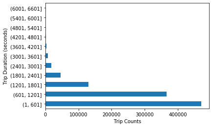

```python
data.trip_duration.groupby(pd.cut(data.trip_duration, np.arange(1,7200,600))).count().plot(kind='barh')
plt.xlabel('Trip Counts')
plt.ylabel('Trip Duration (seconds)')
plt.show()
```

In the above graph, We can observe that most of the trips took 0 - 30 mins to complete.

##### SPEED

```python
data.speed.describe()
```

```
count   1048561.00
mean         14.43
std          14.24
min           0.00
25%           9.13
50%          12.79
75%          17.85
max        6877.35
Name: speed, dtype: float64
```

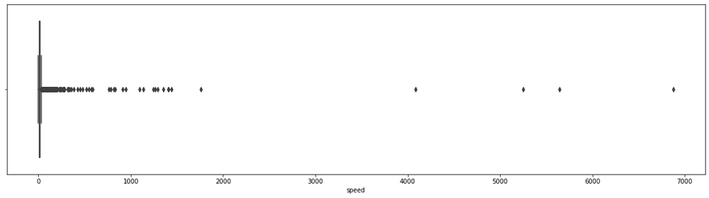

```python
plt.figure(figsize = (20,5))
sns.boxplot(data.speed)
plt.show()
```

Many trips were done at a speed of over 200 km/h.

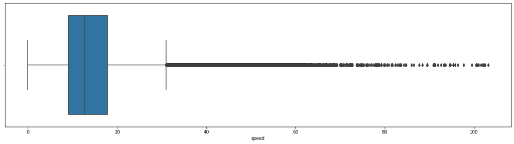

```python
data = data[data.speed <= 104]
plt.figure(figsize = (20,5))
sns.boxplot(data.speed)
plt.show()
```

OBSERVATIONS:

1. Trips over 30 km/h are being considered as outliers.
2. Mostly trips are done at a speed range of 10-20 km/h with an average speed of around 14 km/h.

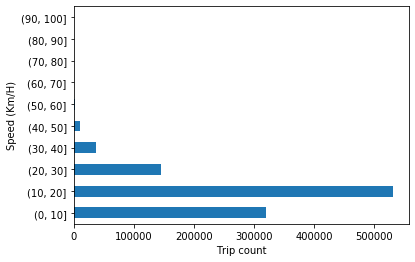

```python
data.speed.groupby(pd.cut(data.speed, np.arange(0,104,10))).count().plot(kind = 'barh')
plt.xlabel('Trip count')
plt.ylabel('Speed (Km/H)')
plt.show()
```

Most of the trips were done at a speed range of 10-20 km/H.

##### Store_and_fwd_flag

```python
data.flag_Y.value_counts(normalize=True)
```

```
0   0.99
1   0.01
Name: flag_Y, dtype: float64
```

```python
data.flag_Y.value_counts()
```

```
0    1042637
1       5809
Name: flag_Y, dtype: int64
```

```python
data.vendor_id[data.flag_Y == 1].value_counts()
```

```
1.00    5809
Name: vendor_id, dtype: int64
```

```python
data[data.flag_Y == 1]
```

|  | id | vendor_id | pickup_datetime | dropoff_datetime | passenger_count | pickup_longitude | pickup_latitude | dropoff_longitude | dropoff_latitude | store_and_fwd_flag | ... | pickup_hour_23.0 | passenger_count_1.0 | passenger_count_2.0 | passenger_count_3.0 | passenger_count_4.0 | passenger_count_5.0 | passenger_count_6.0 | passenger_count_7.0 | passenger_count_8.0 | passenger_count_9.0 |
| --- | --- | --- | --- | --- | --- | --- | --- | --- | --- | --- | --- | --- | --- | --- | --- | --- | --- | --- | --- | --- | --- |
| 348 | id1633648 | 1.00 | 2016-06-20 14:19:00 | 2016-06-20 14:34:00 | 1.00 | -73.98 | 40.75 | -73.95 | 40.77 | Y | ... | 0 | 1 | 0 | 0 | 0 | 0 | 0 | 0 | 0 | 0 |
| 491 | id2042535 | 1.00 | 2016-02-12 12:36:00 | 2016-02-12 12:47:00 | 1.00 | -73.98 | 40.76 | -73.99 | 40.75 | Y | ... | 0 | 1 | 0 | 0 | 0 | 0 | 0 | 0 | 0 | 0 |
| 610 | id0909228 | 1.00 | 2016-05-08 15:02:00 | 2016-05-08 15:17:00 | 1.00 | -73.99 | 40.74 | -74.01 | 40.72 | Y | ... | 0 | 1 | 0 | 0 | 0 | 0 | 0 | 0 | 0 | 0 |
| 774 | id3697489 | 1.00 | 2016-01-13 13:53:00 | 2016-01-13 14:08:00 | 1.00 | -73.95 | 40.78 | -73.98 | 40.78 | Y | ... | 0 | 1 | 0 | 0 | 0 | 0 | 0 | 0 | 0 | 0 |
| 846 | id1026973 | 1.00 | 2016-06-25 21:53:00 | 2016-06-25 22:05:00 | 1.00 | -73.98 | 40.76 | -74.00 | 40.75 | Y | ... | 0 | 1 | 0 | 0 | 0 | 0 | 0 | 0 | 0 | 0 |
| 854 | id1872397 | 1.00 | 2016-06-05 11:44:00 | 2016-06-05 11:56:00 | 1.00 | -73.95 | 40.77 | -73.97 | 40.77 | Y | ... | 0 | 1 | 0 | 0 | 0 | 0 | 0 | 0 | 0 | 0 |
| 1014 | id3003058 | 1.00 | 2016-05-08 02:32:00 | 2016-05-08 03:07:00 | 1.00 | -74.00 | 40.77 | -73.94 | 40.69 | Y | ... | 0 | 1 | 0 | 0 | 0 | 0 | 0 | 0 | 0 | 0 |
| 1031 | id1211472 | 1.00 | 2016-05-12 14:11:00 | 2016-05-12 15:03:00 | 1.00 | -73.95 | 40.79 | -73.79 | 40.64 | Y | ... | 0 | 1 | 0 | 0 | 0 | 0 | 0 | 0 | 0 | 0 |
| 1115 | id2453193 | 1.00 | 2016-03-19 11:25:00 | 2016-03-19 11:31:00 | 4.00 | -73.98 | 40.75 | -73.99 | 40.76 | Y | ... | 0 | 0 | 0 | 0 | 1 | 0 | 0 | 0 | 0 | 0 |
| 1336 | id0775739 | 1.00 | 2016-03-24 16:05:00 | 2016-03-24 16:18:00 | 1.00 | -73.98 | 40.73 | -73.97 | 40.75 | Y | ... | 0 | 1 | 0 | 0 | 0 | 0 | 0 | 0 | 0 | 0 |
| 1478 | id3619640 | 1.00 | 2016-04-08 09:28:00 | 2016-04-08 10:01:00 | 1.00 | -73.86 | 40.77 | -73.98 | 40.76 | Y | ... | 0 | 1 | 0 | 0 | 0 | 0 | 0 | 0 | 0 | 0 |
| 1746 | id2083885 | 1.00 | 2016-04-02 09:54:00 | 2016-04-02 10:06:00 | 1.00 | -73.96 | 40.77 | -73.99 | 40.74 | Y | ... | 0 | 1 | 0 | 0 | 0 | 0 | 0 | 0 | 0 | 0 |
| 1769 | id2892749 | 1.00 | 2016-01-18 15:24:00 | 2016-01-18 15:28:00 | 5.00 | -73.95 | 40.82 | -73.95 | 40.82 | Y | ... | 0 | 0 | 0 | 0 | 0 | 1 | 0 | 0 | 0 | 0 |
| 1863 | id1268779 | 1.00 | 2016-06-02 19:37:00 | 2016-06-02 19:46:00 | 2.00 | -73.95 | 40.77 | -73.96 | 40.77 | Y | ... | 0 | 0 | 1 | 0 | 0 | 0 | 0 | 0 | 0 | 0 |
| 1911 | id0044133 | 1.00 | 2016-06-28 21:28:00 | 2016-06-28 21:35:00 | 1.00 | -73.98 | 40.66 | -73.96 | 40.66 | Y | ... | 0 | 1 | 0 | 0 | 0 | 0 | 0 | 0 | 0 | 0 |
| 1936 | id0619230 | 1.00 | 2016-04-28 15:49:00 | 2016-04-28 16:25:00 | 1.00 | -73.99 | 40.76 | -73.87 | 40.77 | Y | ... | 0 | 1 | 0 | 0 | 0 | 0 | 0 | 0 | 0 | 0 |
| 2658 | id1765114 | 1.00 | 2016-04-25 09:18:00 | 2016-04-25 09:23:00 | 1.00 | -73.98 | 40.79 | -73.97 | 40.80 | Y | ... | 0 | 1 | 0 | 0 | 0 | 0 | 0 | 0 | 0 | 0 |
| 2894 | id0410541 | 1.00 | 2016-02-18 10:09:00 | 2016-02-18 10:20:00 | 1.00 | -73.96 | 40.78 | -73.96 | 40.77 | Y | ... | 0 | 1 | 0 | 0 | 0 | 0 | 0 | 0 | 0 | 0 |
| 3077 | id1358649 | 1.00 | 2016-01-16 19:51:00 | 2016-01-16 20:00:00 | 1.00 | -73.99 | 40.76 | -73.98 | 40.78 | Y | ... | 0 | 1 | 0 | 0 | 0 | 0 | 0 | 0 | 0 | 0 |
| 3517 | id2698335 | 1.00 | 2016-03-23 15:23:00 | 2016-03-23 15:33:00 | 1.00 | -73.99 | 40.76 | -74.00 | 40.76 | Y | ... | 0 | 1 | 0 | 0 | 0 | 0 | 0 | 0 | 0 | 0 |
| 3540 | id2912627 | 1.00 | 2016-06-24 22:30:00 | 2016-06-24 22:51:00 | 1.00 | -74.00 | 40.74 | -73.98 | 40.72 | Y | ... | 0 | 1 | 0 | 0 | 0 | 0 | 0 | 0 | 0 | 0 |
| 3543 | id2918195 | 1.00 | 2016-02-29 02:36:00 | 2016-02-29 02:43:00 | 2.00 | -73.98 | 40.74 | -73.95 | 40.77 | Y | ... | 0 | 0 | 1 | 0 | 0 | 0 | 0 | 0 | 0 | 0 |
| 3847 | id1870644 | 1.00 | 2016-03-28 09:01:00 | 2016-03-28 09:13:00 | 1.00 | -73.95 | 40.77 | -73.97 | 40.76 | Y | ... | 0 | 1 | 0 | 0 | 0 | 0 | 0 | 0 | 0 | 0 |
| 4029 | id1335610 | 1.00 | 2016-05-22 00:03:00 | 2016-05-22 00:29:00 | 1.00 | -73.78 | 40.64 | -73.98 | 40.74 | Y | ... | 0 | 1 | 0 | 0 | 0 | 0 | 0 | 0 | 0 | 0 |
| 4356 | id2450047 | 1.00 | 2016-04-14 17:19:00 | 2016-04-14 17:25:00 | 1.00 | -73.98 | 40.78 | -73.99 | 40.78 | Y | ... | 0 | 1 | 0 | 0 | 0 | 0 | 0 | 0 | 0 | 0 |
| 4359 | id0329403 | 1.00 | 2016-04-21 07:52:00 | 2016-04-21 07:56:00 | 1.00 | -74.01 | 40.73 | -74.00 | 40.73 | Y | ... | 0 | 1 | 0 | 0 | 0 | 0 | 0 | 0 | 0 | 0 |
| 4446 | id1084281 | 1.00 | 2016-02-03 10:47:00 | 2016-02-03 10:53:00 | 1.00 | -73.96 | 40.78 | -73.98 | 40.78 | Y | ... | 0 | 1 | 0 | 0 | 0 | 0 | 0 | 0 | 0 | 0 |
| 4465 | id3276932 | 1.00 | 2016-02-08 12:51:00 | 2016-02-08 13:03:00 | 1.00 | -73.99 | 40.74 | -74.01 | 40.72 | Y | ... | 0 | 1 | 0 | 0 | 0 | 0 | 0 | 0 | 0 | 0 |
| 4961 | id1364909 | 1.00 | 2016-04-02 03:14:00 | 2016-04-02 03:32:00 | 1.00 | -73.99 | 40.73 | -73.96 | 40.77 | Y | ... | 0 | 1 | 0 | 0 | 0 | 0 | 0 | 0 | 0 | 0 |
| 4994 | id3129444 | 1.00 | 2016-05-09 13:37:00 | 2016-05-09 14:15:00 | 2.00 | -73.92 | 40.74 | -73.99 | 40.74 | Y | ... | 0 | 0 | 1 | 0 | 0 | 0 | 0 | 0 | 0 | 0 |
| ... | ... | ... | ... | ... | ... | ... | ... | ... | ... | ... | ... | ... | ... | ... | ... | ... | ... | ... | ... | ... | ... |
| 1043468 | id0057083 | 1.00 | 2016-03-23 06:56:00 | 2016-03-23 06:58:00 | 1.00 | -73.95 | 40.78 | -73.96 | 40.78 | Y | ... | 0 | 1 | 0 | 0 | 0 | 0 | 0 | 0 | 0 | 0 |
| 1043636 | id3113814 | 1.00 | 2016-05-03 18:36:00 | 2016-05-03 18:49:00 | 1.00 | -74.00 | 40.77 | -74.00 | 40.74 | Y | ... | 0 | 1 | 0 | 0 | 0 | 0 | 0 | 0 | 0 | 0 |
| 1043877 | id0741233 | 1.00 | 2016-01-08 17:33:00 | 2016-01-08 17:36:00 | 1.00 | -73.99 | 40.72 | -73.99 | 40.72 | Y | ... | 0 | 1 | 0 | 0 | 0 | 0 | 0 | 0 | 0 | 0 |
| 1044119 | id0643015 | 1.00 | 2016-04-27 07:38:00 | 2016-04-27 07:42:00 | 1.00 | -73.96 | 40.76 | -73.96 | 40.77 | Y | ... | 0 | 1 | 0 | 0 | 0 | 0 | 0 | 0 | 0 | 0 |
| 1044208 | id2620582 | 1.00 | 2016-06-10 15:39:00 | 2016-06-10 15:53:00 | 1.00 | -73.98 | 40.76 | -73.97 | 40.76 | Y | ... | 0 | 1 | 0 | 0 | 0 | 0 | 0 | 0 | 0 | 0 |
| 1044296 | id0067517 | 1.00 | 2016-05-22 05:15:00 | 2016-05-22 05:27:00 | 1.00 | -74.00 | 40.74 | -73.99 | 40.72 | Y | ... | 0 | 1 | 0 | 0 | 0 | 0 | 0 | 0 | 0 | 0 |
| 1044795 | id1993917 | 1.00 | 2016-04-17 20:15:00 | 2016-04-17 20:19:00 | 2.00 | -73.98 | 40.75 | -73.98 | 40.74 | Y | ... | 0 | 0 | 1 | 0 | 0 | 0 | 0 | 0 | 0 | 0 |
| 1044796 | id2597837 | 1.00 | 2016-01-28 16:31:00 | 2016-01-28 16:33:00 | 1.00 | -73.98 | 40.78 | -73.98 | 40.78 | Y | ... | 0 | 1 | 0 | 0 | 0 | 0 | 0 | 0 | 0 | 0 |
| 1045013 | id1667784 | 1.00 | 2016-05-25 08:52:00 | 2016-05-25 09:23:00 | 3.00 | -73.87 | 40.77 | -73.96 | 40.78 | Y | ... | 0 | 0 | 0 | 1 | 0 | 0 | 0 | 0 | 0 | 0 |
| 1045217 | id3838670 | 1.00 | 2016-05-08 18:27:00 | 2016-05-08 19:00:00 | 1.00 | -73.99 | 40.75 | -74.01 | 40.65 | Y | ... | 0 | 1 | 0 | 0 | 0 | 0 | 0 | 0 | 0 | 0 |
| 1045222 | id1868995 | 1.00 | 2016-06-09 07:50:00 | 2016-06-09 07:56:00 | 1.00 | -73.99 | 40.77 | -73.99 | 40.78 | Y | ... | 0 | 1 | 0 | 0 | 0 | 0 | 0 | 0 | 0 | 0 |
| 1045340 | id0890957 | 1.00 | 2016-04-15 21:16:00 | 2016-04-15 21:25:00 | 1.00 | -73.98 | 40.76 | -73.99 | 40.78 | Y | ... | 0 | 1 | 0 | 0 | 0 | 0 | 0 | 0 | 0 | 0 |
| 1045613 | id3261153 | 1.00 | 2016-06-23 19:36:00 | 2016-06-23 20:15:00 | 2.00 | -73.79 | 40.65 | -73.96 | 40.76 | Y | ... | 0 | 0 | 1 | 0 | 0 | 0 | 0 | 0 | 0 | 0 |
| 1045865 | id0864198 | 1.00 | 2016-02-26 09:08:00 | 2016-02-26 09:47:00 | 1.00 | -73.99 | 40.75 | -73.99 | 40.69 | Y | ... | 0 | 1 | 0 | 0 | 0 | 0 | 0 | 0 | 0 | 0 |
| 1045961 | id2167786 | 1.00 | 2016-02-24 10:23:00 | 2016-02-24 10:28:00 | 1.00 | -73.97 | 40.79 | -73.98 | 40.78 | Y | ... | 0 | 1 | 0 | 0 | 0 | 0 | 0 | 0 | 0 | 0 |
| 1046179 | id0660301 | 1.00 | 2016-03-27 01:15:00 | 2016-03-27 01:28:00 | 1.00 | -74.01 | 40.74 | -73.99 | 40.76 | Y | ... | 0 | 1 | 0 | 0 | 0 | 0 | 0 | 0 | 0 | 0 |
| 1046193 | id1491857 | 1.00 | 2016-05-17 23:15:00 | 2016-05-17 23:28:00 | 1.00 | -73.99 | 40.72 | -73.95 | 40.70 | Y | ... | 1 | 1 | 0 | 0 | 0 | 0 | 0 | 0 | 0 | 0 |
| 1046289 | id0648965 | 1.00 | 2016-01-12 08:54:00 | 2016-01-12 09:12:00 | 1.00 | -74.00 | 40.76 | -73.96 | 40.79 | Y | ... | 0 | 1 | 0 | 0 | 0 | 0 | 0 | 0 | 0 | 0 |
| 1046290 | id3916225 | 1.00 | 2016-01-14 08:59:00 | 2016-01-14 09:18:00 | 1.00 | -73.96 | 40.77 | -73.99 | 40.78 | Y | ... | 0 | 1 | 0 | 0 | 0 | 0 | 0 | 0 | 0 | 0 |
| 1046488 | id3337244 | 1.00 | 2016-04-23 20:06:00 | 2016-04-23 20:14:00 | 1.00 | -73.99 | 40.76 | -73.98 | 40.77 | Y | ... | 0 | 1 | 0 | 0 | 0 | 0 | 0 | 0 | 0 | 0 |
| 1046769 | id1348626 | 1.00 | 2016-02-12 01:05:00 | 2016-02-12 01:09:00 | 1.00 | -73.95 | 40.79 | -73.96 | 40.77 | Y | ... | 0 | 1 | 0 | 0 | 0 | 0 | 0 | 0 | 0 | 0 |
| 1046824 | id1388278 | 1.00 | 2016-03-10 11:00:00 | 2016-03-10 11:04:00 | 1.00 | -73.98 | 40.76 | -73.97 | 40.76 | Y | ... | 0 | 1 | 0 | 0 | 0 | 0 | 0 | 0 | 0 | 0 |
| 1046896 | id2869886 | 1.00 | 2016-05-23 00:34:00 | 2016-05-23 01:00:00 | 2.00 | -73.78 | 40.64 | -73.99 | 40.74 | Y | ... | 0 | 0 | 1 | 0 | 0 | 0 | 0 | 0 | 0 | 0 |
| 1047325 | id1759618 | 1.00 | 2016-04-21 16:38:00 | 2016-04-21 17:49:00 | 1.00 | -73.98 | 40.74 | -73.79 | 40.65 | Y | ... | 0 | 1 | 0 | 0 | 0 | 0 | 0 | 0 | 0 | 0 |
| 1047380 | id2895658 | 1.00 | 2016-01-08 15:51:00 | 2016-01-08 16:06:00 | 2.00 | -74.01 | 40.71 | -73.97 | 40.75 | Y | ... | 0 | 0 | 1 | 0 | 0 | 0 | 0 | 0 | 0 | 0 |
| 1047470 | id0004552 | 1.00 | 2016-01-26 17:59:00 | 2016-01-26 18:21:00 | 1.00 | -73.96 | 40.71 | -73.96 | 40.68 | Y | ... | 0 | 1 | 0 | 0 | 0 | 0 | 0 | 0 | 0 | 0 |
| 1047623 | id0983635 | 1.00 | 2016-02-03 10:23:00 | 2016-02-03 10:31:00 | 1.00 | -73.99 | 40.73 | -73.99 | 40.74 | Y | ... | 0 | 1 | 0 | 0 | 0 | 0 | 0 | 0 | 0 | 0 |
| 1048232 | id0719019 | 1.00 | 2016-04-28 01:19:00 | 2016-04-28 01:27:00 | 1.00 | -74.01 | 40.73 | -73.99 | 40.72 | Y | ... | 0 | 1 | 0 | 0 | 0 | 0 | 0 | 0 | 0 | 0 |
| 1048383 | id3068837 | 1.00 | 2016-02-02 17:07:00 | 2016-02-02 17:25:00 | 1.00 | -73.97 | 40.79 | -73.96 | 40.77 | Y | ... | 0 | 1 | 0 | 0 | 0 | 0 | 0 | 0 | 0 | 0 |
| 1048427 | id1693618 | 1.00 | 2016-06-18 14:05:00 | 2016-06-18 14:16:00 | 2.00 | -73.97 | 40.78 | -73.99 | 40.77 | Y | ... | 0 | 0 | 1 | 0 | 0 | 0 | 0 | 0 | 0 | 0 |

5809 rows × 62 columns

##### TOTAL TRIPS PER HOUR

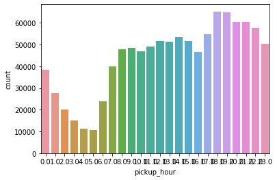

```python
sns.countplot(data.pickup_hour)
plt.show()
```

Pickups start increasing from 6AM in the mornign and then declines from late evening i.e 8PM.

##### TOTAL TRIPS PER WEEKDAY

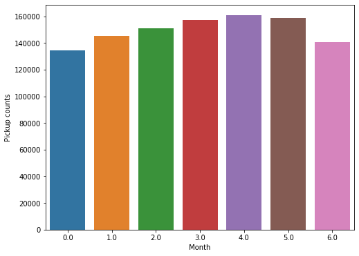

```python
plt.figure(figsize = (8,6))
sns.countplot(data.weekday_num)
plt.xlabel(' Month ')
plt.ylabel('Pickup counts')
plt.show()
```

Taxi pickup trens increaes from Monday till Friday and then declines from Saturday till Monday.

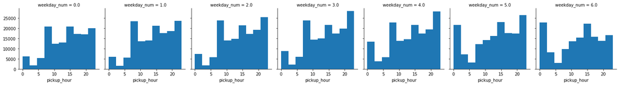

```python
n = sns.FacetGrid(data, col='weekday_num')
n.map(plt.hist, 'pickup_hour')
plt.show()
```

##### TOTAL TRIPS PER MONTH

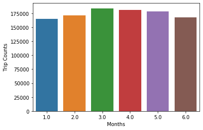

```python
sns.countplot(data.month)
plt.ylabel('Trip Counts')
plt.xlabel('Months')
plt.show()
```

Data shown above is balanced across the months.

##### BIVARIATE ANALYSIS

Trip Duration per hour

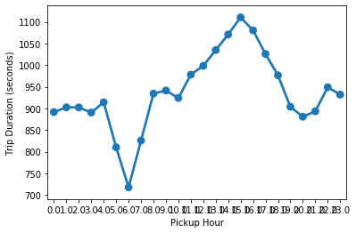

```python
group1 = data.groupby('pickup_hour').trip_duration.mean()
sns.pointplot(group1.index, group1.values)
plt.ylabel('Trip Duration (seconds)')
plt.xlabel('Pickup Hour')
plt.show()
```

1. Average trip duration is lowest at 6 AM when there is minimal traffic on the roads.
2. Average trip duration is generally highest around 3 PM during the busy streets.
3. Trip duration on an average is similar during early morning hours i.e. before 6 AM & late evening hours i.e. after 6 PM.

Trip Duration per Weekday

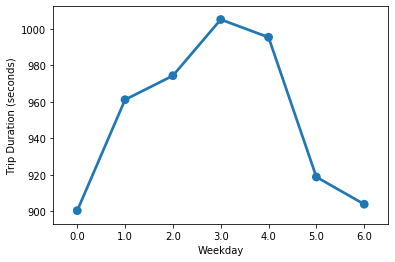

```python
group2 = data.groupby('weekday_num').trip_duration.mean()
sns.pointplot(group2.index, group2.values)
plt.ylabel('Trip Duration (seconds)')
plt.xlabel('Weekday')
plt.show()
```

Trip duration on thursday is longest among all days.

Trip Duration per Month

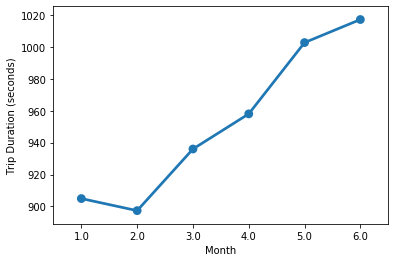

```python
group3 = data.groupby('month').trip_duration.mean()
sns.pointplot(group3.index, group3.values)
plt.ylabel('Trip Duration (seconds)')
plt.xlabel('Month')
plt.show()
```

1. Trip duration is the lowest during february.
2. The difference between each month is not much. It has increased over a period of 6 months.

##### Trip Duration per Vendor

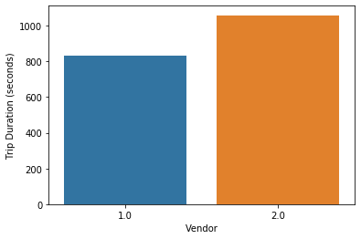

```python
group4 = data.groupby('vendor_id').trip_duration.mean()
sns.barplot(group4.index, group4.values)
plt.ylabel('Trip Duration (seconds)')
plt.xlabel('Vendor')
plt.show()
```

Trip duration for vendor 2 is higher than vendor 1 by approximately atleast 3 minutes per trip.

Trip Duration v/s Flag

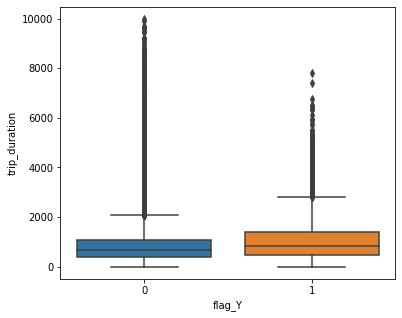

```python
plt.figure(figsize = (6,5))
plot_dur = data.loc[(data.trip_duration < 10000)]
sns.boxplot(x = "flag_Y", y = "trip_duration", data = plot_dur)
plt.show()
```

##### Distance per hour

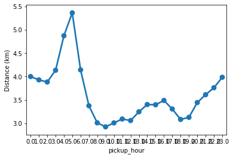

```python
group5 = data.groupby('pickup_hour').distance.mean()
sns.pointplot(group5.index, group5.values)
plt.ylabel('Distance (km)')
plt.show()
```

1. Trip distance is highest during early morning hours.
2. Trip distance is fairly equal from morning till the evening varying around 3 - 3.5 kms.
3. It starts increasing gradually towards the late night hours starting from evening till 5 AM and decrease steeply towards morning.

##### Distance per Weekday

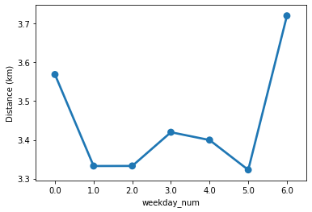

```python
group6 = data.groupby('weekday_num').distance.mean()
sns.pointplot(group6.index, group6.values)
plt.ylabel('Distance (km)')
plt.show()
```

##### Distance per Month

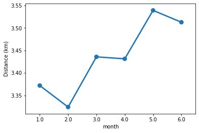

```python
group7 = data.groupby('month').distance.mean()
sns.pointplot(group7.index, group7.values)
plt.ylabel('Distance (km)')
plt.show()
```

##### Distance per Vendor

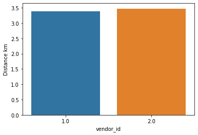

```python
group8 = data.groupby('vendor_id').distance.mean()
sns.barplot(group8.index, group8.values)
plt.ylabel("Distance km")
plt.show()
```

##### Distance v/s Flag

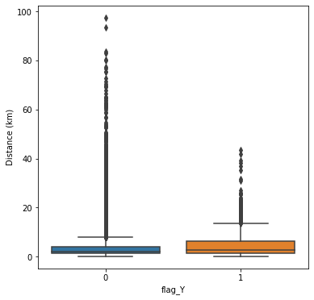

```python
plt.figure(figsize = (6,6))
plot_dist = data.loc[(data.distance < 100)]
sns.boxplot(x = "flag_Y", y = "distance", data = plot_dist)
plt.ylabel('Distance (km)')
plt.show()
```

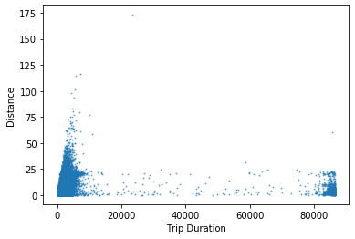

```python
plt.scatter(data.trip_duration, data.distance , s=1, alpha=0.5)
plt.ylabel('Distance')
plt.xlabel('Trip Duration')
plt.show()
```

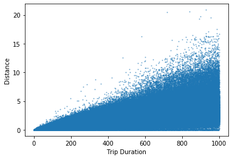

```python
dur_dist = data.loc[(data.distance < 50) & (data.trip_duration < 1000), ['distance','trip_duration']]
plt.scatter(dur_dist.trip_duration, dur_dist.distance , s=1, alpha=0.5)
plt.ylabel('Distance')
plt.xlabel('Trip Duration')
plt.show()
```

```python
data = data[~((data.distance == 0) & (data.trip_duration >= 60))]
```

```python
duo = data.loc[(data['distance'] <= 1) & (data['trip_duration'] >= 3600),['distance','trip_duration']].reset_index(drop=True)
```

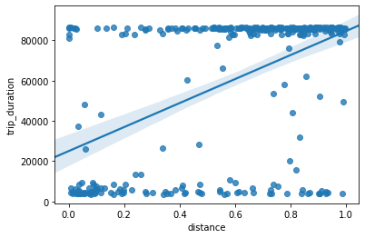

```python
sns.regplot(duo.distance, duo.trip_duration)
plt.show()
```

```python
data = data[~((data['distance'] <= 1) & (data['trip_duration'] >= 3600))]
```

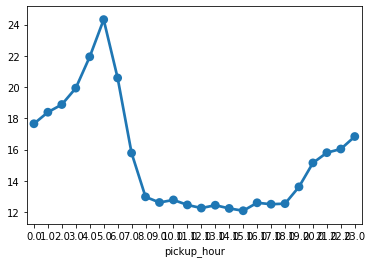

```python
group9 = data.groupby('pickup_hour').speed.mean()
sns.pointplot(group9.index, group9.values)
plt.show()
```

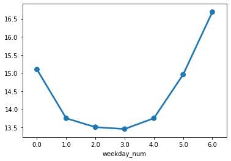

```python
group10 = data.groupby('weekday_num').speed.mean()
sns.pointplot(group10.index, group10.values)
plt.show()
```

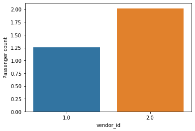

```python
group9 = data.groupby('vendor_id').passenger_count.mean()
sns.barplot(group9.index, group9.values)
plt.ylabel('Passenger count')
plt.show()
```

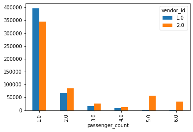

```python
data.groupby('passenger_count').vendor_id.value_counts().reset_index(name='count').pivot("passenger_count","vendor_id","count").plot(kind='bar')
plt.show()
```

```python
#First chech the index of the features and label
list(zip( range(0,len(data.columns)),data.columns))
```

```
[(0, 'id'),
 (1, 'vendor_id'),
 (2, 'pickup_datetime'),
 (3, 'dropoff_datetime'),
 (4, 'passenger_count'),
 (5, 'pickup_longitude'),
 (6, 'pickup_latitude'),
 (7, 'dropoff_longitude'),
 (8, 'dropoff_latitude'),
 (9, 'store_and_fwd_flag'),
 (10, 'trip_duration'),
 (11, 'weekday'),
 (12, 'month'),
 (13, 'weekday_num'),
 (14, 'pickup_hour'),
 (15, 'distance'),
 (16, 'speed'),
 (17, 'flag_Y'),
 (18, 'vendor_id_2.0'),
 (19, 'month_2.0'),
 (20, 'month_3.0'),
 (21, 'month_4.0'),
 (22, 'month_5.0'),
 (23, 'month_6.0'),
 (24, 'weekday_num_1.0'),
 (25, 'weekday_num_2.0'),
 (26, 'weekday_num_3.0'),
 (27, 'weekday_num_4.0'),
 (28, 'weekday_num_5.0'),
 (29, 'weekday_num_6.0'),
 (30, 'pickup_hour_1.0'),
 (31, 'pickup_hour_2.0'),
 (32, 'pickup_hour_3.0'),
 (33, 'pickup_hour_4.0'),
 (34, 'pickup_hour_5.0'),
 (35, 'pickup_hour_6.0'),
 (36, 'pickup_hour_7.0'),
 (37, 'pickup_hour_8.0'),
 (38, 'pickup_hour_9.0'),
 (39, 'pickup_hour_10.0'),
 (40, 'pickup_hour_11.0'),
 (41, 'pickup_hour_12.0'),
 (42, 'pickup_hour_13.0'),
 (43, 'pickup_hour_14.0'),
 (44, 'pickup_hour_15.0'),
 (45, 'pickup_hour_16.0'),
 (46, 'pickup_hour_17.0'),
 (47, 'pickup_hour_18.0'),
 (48, 'pickup_hour_19.0'),
 (49, 'pickup_hour_20.0'),
 (50, 'pickup_hour_21.0'),
 (51, 'pickup_hour_22.0'),
 (52, 'pickup_hour_23.0'),
 (53, 'passenger_count_1.0'),
 (54, 'passenger_count_2.0'),
 (55, 'passenger_count_3.0'),
 (56, 'passenger_count_4.0'),
 (57, 'passenger_count_5.0'),
 (58, 'passenger_count_6.0'),
 (59, 'passenger_count_7.0'),
 (60, 'passenger_count_8.0'),
 (61, 'passenger_count_9.0')]
```

```python
Y = data.iloc[:,10].values
X = data.iloc[:,range(15,61)].values
```

```python
print("Let's append {} rows of 1's as the first column in the X array".format(X.shape[0]))
```

```
Let's append 1045056 rows of 1's as the first column in the X array
```

```python
X1 = np.append(arr = np.ones((X.shape[0],1)).astype(int), values = X, axis = 1)
```

```python
X1.shape
```

```
(1045056, 47)
```

```python
# X_opt = X1[:,[0,1,3,4,6,7,8,9,10,11]]
# regressor_OLS = sm.OLS(endog = Y, exog = X_opt).fit()
# regressor_OLS.summary()
```

```python
!pip install statsmodels
```

```python
#Select all the features in X array
import statsmodels.api as sm
X_opt = X1[:,range(0,46)]
regressor_OLS = sm.OLS(endog = Y, exog = X_opt).fit()

#Fetch p values for each feature
p_Vals = regressor_OLS.pvalues

#define significance level for accepting the feature.
sig_Level = 0.05

#Loop to iterate over features and remove the feature with p value less than the sig_level
while max(p_Vals) > sig_Level:
    print("Probability values of each feature \n")
    print(p_Vals)
    X_opt = np.delete(X_opt, np.argmax(p_Vals), axis = 1)
    print("\n")
    print("Feature at index {} is removed \n".format(str(np.argmax(p_Vals))))
    print(str(X_opt.shape[1]-1) + " dimensions remaining now... \n")
    regressor_OLS = sm.OLS(endog = Y, exog = X_opt).fit()
    p_Vals = regressor_OLS.pvalues
    print("=================================================================\n")

#Print final summary
print("Final stat summary with optimal {} features".format(str(X_opt.shape[1]-1)))
regressor_OLS.summary()
```

[output not shown]

[output cut: 192 more lines]

```
 4.88096885e-016 3.79706023e-006 5.79831344e-003 4.15154488e-013
 1.12158469e-014 6.83019943e-021 2.04657518e-022 3.46312291e-016
 1.61767146e-016 7.03917848e-022 5.08850364e-016 1.08166284e-013
 4.79420897e-021 1.51971075e-020 7.34501683e-019 6.21541583e-009
 1.48299353e-002 0.00000000e+000 0.00000000e+000 0.00000000e+000
 0.00000000e+000 0.00000000e+000 0.00000000e+000]


Feature at index 3 is removed

33 dimensions remaining now...

=================================================================

Final stat summary with optimal 33 features
```

OLS Regression Results

| Dep. Variable: | y | R-squared (uncentered): | 0.154 |
| --- | --- | --- | --- |
| Model: | OLS | Adj. R-squared (uncentered): | 0.154 |
| Method: | Least Squares | F-statistic: | 5577. |
| Date: | Mon, 09 Dec 2019 | Prob (F-statistic): | 0.00 |
| Time: | 22:56:18 | Log-Likelihood: | -9.7905e+06 |
| No. Observations: | 1045056 | AIC: | 1.958e+07 |
| Df Residuals: | 1045022 | BIC: | 1.958e+07 |
| Df Model: | 34 |  |  |
| Covariance Type: | nonrobust |  |  |

|  | coef | std err | t | P>\|t\| | [0.025 | 0.975] |
| --- | --- | --- | --- | --- | --- | --- |
| x1 | 228.2984 | 0.855 | 267.094 | 0.000 | 226.623 | 229.974 |
| x2 | -87.1346 | 0.464 | -187.946 | 0.000 | -88.043 | -86.226 |
| x3 | 184.9068 | 5.824 | 31.747 | 0.000 | 173.491 | 196.322 |
| x4 | 17.6072 | 7.532 | 2.338 | 0.019 | 2.845 | 32.369 |
| x5 | 25.0239 | 7.717 | 3.243 | 0.001 | 9.900 | 40.148 |
| x6 | 39.4143 | 7.953 | 4.956 | 0.000 | 23.826 | 55.003 |
| x7 | 89.0520 | 8.455 | 10.532 | 0.000 | 72.480 | 105.624 |
| x8 | 79.9937 | 18.679 | 4.282 | 0.000 | 43.383 | 116.605 |
| x9 | 139.3996 | 21.422 | 6.507 | 0.000 | 97.413 | 181.386 |
| x10 | 176.3645 | 24.400 | 7.228 | 0.000 | 128.540 | 224.189 |
| x11 | 209.6392 | 27.767 | 7.550 | 0.000 | 155.217 | 264.062 |
| x12 | 231.2117 | 28.491 | 8.115 | 0.000 | 175.370 | 287.053 |
| x13 | 92.1067 | 19.920 | 4.624 | 0.000 | 53.065 | 131.149 |
| x14 | -44.3162 | 16.077 | -2.757 | 0.006 | -75.826 | -12.806 |
| x15 | -109.0209 | 15.041 | -7.248 | 0.000 | -138.501 | -79.541 |
| x16 | -115.5454 | 14.959 | -7.724 | 0.000 | -144.864 | -86.227 |
| x17 | -142.0539 | 15.153 | -9.375 | 0.000 | -171.753 | -112.355 |
| x18 | -145.1832 | 14.907 | -9.739 | 0.000 | -174.400 | -115.967 |
| x19 | -119.4466 | 14.644 | -8.157 | 0.000 | -148.149 | -90.744 |
| x20 | -120.9570 | 14.670 | -8.245 | 0.000 | -149.711 | -92.203 |
| x21 | -138.9450 | 14.453 | -9.614 | 0.000 | -167.272 | -110.618 |
| x22 | -119.0132 | 14.672 | -8.111 | 0.000 | -147.771 | -90.256 |
| x23 | -113.0802 | 15.221 | -7.429 | 0.000 | -142.913 | -83.248 |
| x24 | -134.7822 | 14.317 | -9.414 | 0.000 | -162.843 | -106.721 |
| x25 | -125.0979 | 13.469 | -9.288 | 0.000 | -151.496 | -98.699 |
| x26 | -119.1959 | 13.443 | -8.867 | 0.000 | -145.543 | -92.849 |
| x27 | -79.8931 | 13.754 | -5.809 | 0.000 | -106.850 | -52.937 |
| x28 | -33.4108 | 13.725 | -2.434 | 0.015 | -60.311 | -6.511 |
| x29 | 1352.9668 | 10.706 | 126.370 | 0.000 | 1331.983 | 1373.951 |
| x30 | 1338.0074 | 12.559 | 106.535 | 0.000 | 1313.392 | 1362.623 |
| x31 | 1363.3648 | 17.150 | 79.499 | 0.000 | 1329.752 | 1396.977 |
| x32 | 1341.6850 | 22.372 | 59.972 | 0.000 | 1297.837 | 1385.533 |
| x33 | 1352.2705 | 16.506 | 81.924 | 0.000 | 1319.918 | 1384.623 |
| x34 | 1349.1911 | 19.070 | 70.748 | 0.000 | 1311.814 | 1386.568 |

| Omnibus: | 2634904.276 | Durbin-Watson: | 2.002 |
| --- | --- | --- | --- |
| Prob(Omnibus): | 0.000 | Jarque-Bera (JB): | 29945983558.596 |
| Skew: | 28.454 | Prob(JB): | 0.00 |
| Kurtosis: | 830.333 | Cond. No. | 263. |

Warnings:  
[1] Standard Errors assume that the covariance matrix of the errors is correctly specified.

```python
#Split raw data
X_train, X_test, y_train, y_test = train_test_split(X,Y, random_state=4, test_size=0.2)

#Split data from the feature selection group
X_train_fs, X_test_fs, y_train_fs, y_test_fs = train_test_split(X_opt,Y, random_state=4, test_size=0.2)
```

```python
X_train_pca, X_test_pca, y_train_pca, y_test_pca = train_test_split(X,Y, random_state=4, test_size=0.2)
```

```python
from sklearn.preprocessing import StandardScaler
scaler = StandardScaler()
X_train_pca = scaler.fit_transform(X_train_pca)
X_test_pca = scaler.transform(X_test_pca)
```

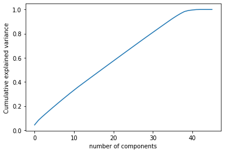

```python
from sklearn.decomposition import PCA
pca = PCA().fit(X_train_pca)
plt.plot(np.cumsum(pca.explained_variance_ratio_))
plt.xlabel("number of components")
plt.ylabel("Cumulative explained variance")
plt.show()
```

```python
arr = np.cumsum(np.round(pca.explained_variance_ratio_, decimals=4)*100)
list(zip(range(1,len(arr)), arr))
```

```
[(1, 4.32),
 (2, 8.26),
 (3, 11.29),
 (4, 14.149999999999999),
 (5, 16.99),
 (6, 19.77),
 (7, 22.52),
 (8, 25.24),
 (9, 27.909999999999997),
 (10, 30.569999999999997),
 (11, 33.15),
 (12, 35.72),
 (13, 38.15),
 (14, 40.57),
 (15, 42.99),
 (16, 45.400000000000006),
 (17, 47.81),
 (18, 50.21),
 (19, 52.61),
 (20, 55.0),
 (21, 57.39),
 (22, 59.78),
 (23, 62.160000000000004),
 (24, 64.54),
 (25, 66.92),
 (26, 69.3),
 (27, 71.67),
 (28, 74.04),
 (29, 76.39),
 (30, 78.72),
 (31, 81.05),
 (32, 83.36999999999999),
 (33, 85.67999999999999),
 (34, 87.99),
 (35, 90.28999999999999),
 (36, 92.55),
 (37, 94.66),
 (38, 96.6),
 (39, 98.30999999999999),
 (40, 99.16999999999999),
 (41, 99.6),
 (42, 99.94),
 (43, 100.03),
 (44, 100.03),
 (45, 100.03)]
```

```python
pca_10 = PCA(n_components=40)
X_train_pca = pca_10.fit_transform(X_train_pca)
X_test_pca = pca_10.transform(X_test_pca)
```

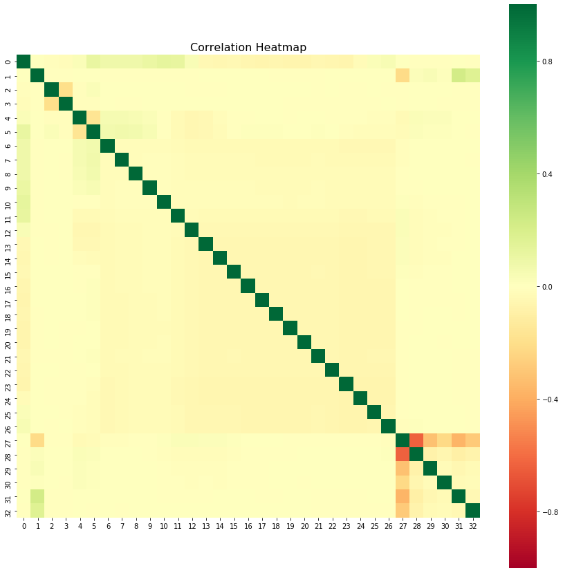

```python
plt.figure(figsize=(15,15))
corr = pd.DataFrame(X_train_fs[:,1:]).corr()
corr.index = pd.DataFrame(X_train_fs[:,1:]).columns
sns.heatmap(corr, cmap='RdYlGn', vmin=-1, vmax=1, square=True)
plt.title("Correlation Heatmap", fontsize=16)
plt.show()
```

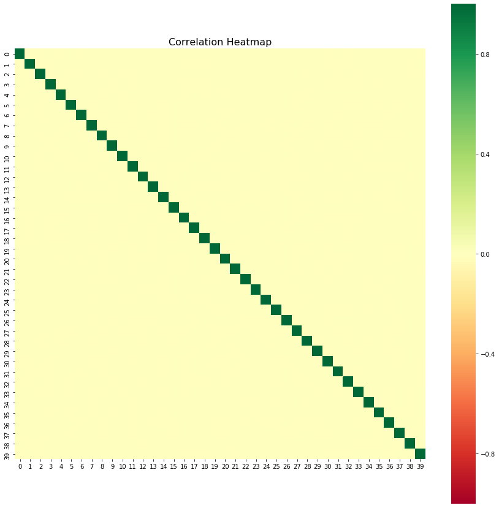

```python
plt.figure(figsize=(15,15))
corr = pd.DataFrame(X_train_pca).corr()
corr.index = pd.DataFrame(X_train_pca).columns
sns.heatmap(corr, cmap='RdYlGn', vmin=-1, vmax=1, square=True)
plt.title("Correlation Heatmap", fontsize=16)
plt.show()
```

# Linear Regression

Performing Linear Regression on Raw , feature selection group and Feature extraction group

```python
#Linear regressor for the raw data
regressor = LinearRegression()
regressor.fit(X_train,y_train)

#Linear regressor for the Feature selection group
regressor1 = LinearRegression()
regressor1.fit(X_train_fs,y_train_fs)

#Linear regressor for the Feature extraction group
regressor2 = LinearRegression()
regressor2.fit(X_train_pca,y_train_pca)
```

```
LinearRegression(copy_X=True, fit_intercept=True, n_jobs=None, normalize=False)
```

```python
regressor1Score=regressor1.score(X_train_fs,y_train_fs)
print(regressor1Score)
regressor2Score=regressor2.score(X_train_pca,y_train_pca)
print(regressor2Score)
```

```
0.06797653677020599
0.0678972284347037
```

```python
#Predict from the test features of raw data
y_pred = regressor.predict(X_test)

#Predict from the test features of Feature Selection group
y_pred = regressor1.predict(X_test_fs)

#Predict from the test features of Feature Extraction group
y_pred_pca = regressor2.predict(X_test_pca)
print(y_pred)
print(y_pred_pca)
```

```
[4243.02798399  981.68337127 1240.59381937 ...  645.82799916 1634.68487586
 3004.57789644]
[4243.80265281  994.99028725 1217.43971085 ...  654.24471333 1662.25863737
 2972.2240379 ]
```

```python
#Evaluate the regressor on the raw data
print('RMSE score for the Multiple LR raw is : {}'.format(np.sqrt(metrics.mean_squared_error(y_test,y_pred))))
print('Variance score for the Multiple LR raw is : %.2f' % regressor.score(X_test, y_test))
print("\n")

#Evaluate the regressor on the Feature selection group
print('RMSE score for the Multiple LR FS is : {}'.format(np.sqrt(metrics.mean_squared_error(y_test_fs,y_pred))))
print('Variance score for the Multiple LR FS is : %.2f' % regressor1.score(X_test_fs, y_test_fs))
print("\n")

#Evaluate the regressor on the Feature extraction group
print('RMSE score for the Multiple LR PCA is : {}'.format(np.sqrt(metrics.mean_squared_error(y_test_pca,y_pred_pca))))
print('Variance score for the Multiple LR PCA is : %.2f' % regressor2.score(X_test_pca, y_test_pca))
```

```
RMSE score for the Multiple LR raw is : 2889.2271050923614
Variance score for the Multiple LR raw is : 0.07


RMSE score for the Multiple LR FS is : 2889.2271050923614
Variance score for the Multiple LR FS is : 0.07


RMSE score for the Multiple LR PCA is : 2889.3720861197316
Variance score for the Multiple LR PCA is : 0.07
```

```python
X_train.shape
```

```
(836044, 46)
```

```python
#Find linear correlation of each feature with the target variable
from scipy.stats import pearsonr
df1 = pd.DataFrame(np.concatenate((X_train,y_train.reshape(len(y_train),1)),axis=1))
df1.columns = df1.columns.astype(str)

features = df1.iloc[:,:46].columns.tolist()
target = df1.iloc[:,46].name

correlations = {}
for f in features:
    data_temp = df1[[f,target]]
    x1 = data_temp[f].values
    x2 = data_temp[target].values
    key = f + ' vs ' + target
    correlations[key] = pearsonr(x1,x2)[0]

data_correlations = pd.DataFrame(correlations, index=['Value']).T
data_correlations.loc[data_correlations['Value'].abs().sort_values(ascending=False).index]
```

|  | Value |
| --- | --- |
| 0 vs 46 | 0.18 |
| 1 vs 46 | -0.05 |
| 3 vs 46 | 0.03 |
| 38 vs 46 | -0.01 |
| 20 vs 46 | -0.01 |
| 29 vs 46 | 0.01 |
| 30 vs 46 | 0.01 |
| 8 vs 46 | 0.01 |
| 7 vs 46 | 0.01 |
| 4 vs 46 | -0.01 |
| 28 vs 46 | 0.01 |
| 11 vs 46 | 0.01 |
| 21 vs 46 | -0.01 |
| 39 vs 46 | 0.01 |
| 42 vs 46 | 0.01 |
| 27 vs 46 | 0.01 |
| 34 vs 46 | -0.01 |
| 13 vs 46 | -0.01 |
| 31 vs 46 | 0.01 |
| 12 vs 46 | 0.01 |
| 14 vs 46 | -0.01 |
| 40 vs 46 | 0.01 |
| 43 vs 46 | 0.00 |
| 26 vs 46 | 0.00 |
| 19 vs 46 | -0.00 |
| 35 vs 46 | -0.00 |
| 33 vs 46 | -0.00 |
| 41 vs 46 | 0.00 |
| 15 vs 46 | -0.00 |
| 2 vs 46 | 0.00 |
| 16 vs 46 | -0.00 |
| 10 vs 46 | 0.00 |
| 32 vs 46 | 0.00 |
| 5 vs 46 | -0.00 |
| 24 vs 46 | -0.00 |
| 37 vs 46 | -0.00 |
| 22 vs 46 | -0.00 |
| 17 vs 46 | -0.00 |
| 25 vs 46 | 0.00 |
| 18 vs 46 | -0.00 |
| 36 vs 46 | -0.00 |
| 23 vs 46 | -0.00 |
| 6 vs 46 | -0.00 |
| 9 vs 46 | 0.00 |
| 44 vs 46 | nan |
| 45 vs 46 | nan |

# Random Forest Regression

Implementing Random forest Regression for Raw data, Feature Selection group data, Feature Extraction group data

```python
#instantiate the object for the Random Forest Regressor with default params from raw data
regressor_rfraw = RandomForestRegressor(n_jobs=-1)
```

```python
#instantiate the object for the Random Forest Regressor with default params for Feature Selection Group
regressor_rf = RandomForestRegressor(n_jobs=-1)

# #instantiate the object for the Random Forest Regressor with tuned hyper parameters for Feature Selection Group
# regressor_rf1 = RandomForestRegressor(n_estimators = 26,
#                                      max_depth = 22,
#                                      min_samples_split = 9,
#                                      n_jobs=-1)
```

```python
#instantiate the object for the Random Forest Regressor for Feature Extraction Group
regressor_rf2 = RandomForestRegressor(n_jobs=-1)
```

```python
#Train the object with default params for raw data
regressor_rfraw.fit(X_train,y_train)
```

```
RandomForestRegressor(bootstrap=True, criterion='mse', max_depth=None,
                      max_features='auto', max_leaf_nodes=None,
                      min_impurity_decrease=0.0, min_impurity_split=None,
                      min_samples_leaf=1, min_samples_split=2,
                      min_weight_fraction_leaf=0.0, n_estimators=10, n_jobs=-1,
                      oob_score=False, random_state=None, verbose=0,
                      warm_start=False)
```

```python
#Train the object with default params for Feature Selection Group
regressor_rf.fit(X_train_fs,y_train_fs)
# #Train the object with tuned params for Feature Selection Group
# regressor_rf1.fit(X_train_fs,y_train_fs)
```

```
RandomForestRegressor(bootstrap=True, criterion='mse', max_depth=None,
                      max_features='auto', max_leaf_nodes=None,
                      min_impurity_decrease=0.0, min_impurity_split=None,
                      min_samples_leaf=1, min_samples_split=2,
                      min_weight_fraction_leaf=0.0, n_estimators=10, n_jobs=-1,
                      oob_score=False, random_state=None, verbose=0,
                      warm_start=False)
```

```python
# #Train the object with default params for Feature Extraction Group
regressor_rf2.fit(X_train_pca,y_train_pca)
```

```
RandomForestRegressor(bootstrap=True, criterion='mse', max_depth=None,
                      max_features='auto', max_leaf_nodes=None,
                      min_impurity_decrease=0.0, min_impurity_split=None,
                      min_samples_leaf=1, min_samples_split=2,
                      min_weight_fraction_leaf=0.0, n_estimators=10, n_jobs=-1,
                      oob_score=False, random_state=None, verbose=0,
                      warm_start=False)
```

```python
print("\n")
```

```python
#Predict the output with object of default params for Feature Selection Group
y_pred_rfraw = regressor_rfraw.predict(X_test)

#Predict the output with object of default params for Feature Selection Group
y_pred_rf = regressor_rf.predict(X_test_fs)

# #Predict the output with object of hyper tuned params for Feature Selection Group
# y_pred_rf1 = regressor_rf1.predict(X_test_fs)

#Predict the output with object of PCA params for Feature Extraction Group
y_pred_rfpca = regressor_rf2.predict(X_test_pca)

print("\n")
```

```python
#Evaluate the model with default params for raw data
print('RMSE score for the RF regressor raw is : {}'.format(np.sqrt(metrics.mean_squared_error(y_test,y_pred_rfraw))))
print('RMSLE score for the RF regressor raw is : {}'.format(np.sqrt(metrics.mean_squared_log_error(y_test,y_pred_rfraw))))
print('Variance score for the RF regressor raw is : %.2f' % regressor_rfraw.score(X_test, y_test))

print("\n")

#Evaluate the model with default params for Feature Selection Group
print('RMSE score for the RF regressor is : {}'.format(np.sqrt(metrics.mean_squared_error(y_test_fs,y_pred_rf))))
print('RMSLE score for the RF regressor is : {}'.format(np.sqrt(metrics.mean_squared_log_error(y_test_fs,y_pred_rf))))
print('Variance score for the RF regressor is : %.2f' % regressor_rf.score(X_test_fs, y_test_fs))

# print("\n")

# #Evaluate the model with tuned params for Feature Selection Group
# print('RMSE score for the RF regressor1 is : {}'.format(np.sqrt(metrics.mean_squared_error(y_test_fs,y_pred_rf1))))
# print('RMSLE score for the RF regressor1 is : {}'.format(np.sqrt(metrics.mean_squared_log_error(y_test_fs,y_pred_rf1))))
# print('Variance score for the RF regressor1 is : %.2f' % regressor_rf1.score(X_test_fs, y_test_fs))

print("\n")

#Evaluate the model with PCA params  for Feature Extraction Group
print('RMSE score for the RF regressor2 is : {}'.format(np.sqrt(metrics.mean_squared_error(y_test_pca, y_pred_rfpca))))
print('Variance score for the RF regressor2 is : %.2f' % regressor_rf2.score(X_test_pca, y_test_pca))
```

```
RMSE score for the RF regressor raw is : 140.02183751475684
RMSLE score for the RF regressor raw is : 0.03297464429776637
Variance score for the RF regressor raw is : 1.00


RMSE score for the RF regressor is : 152.1917327149685
RMSLE score for the RF regressor is : 0.03023559053326822
Variance score for the RF regressor is : 1.00


RMSE score for the RF regressor2 is : 1327.9143485507955
Variance score for the RF regressor2 is : 0.80
```

##### SUMMARY:

All the estimated times are calculated to travel from one zone of New York city to another zone. Data exploration and variable analysis is a very important aspect. we also cleaned the data while exploring as there were some outliers. We did feature engineering to filter and gather only the optimal features. Then we finally trained the models on the optimal features.

##### ROLES AND RESPONSIBILITIES:

1. Implementing Linear Regression on Raw data - Deepika Chowdary Battula
2. Implementing Random Forest Regression on Raw data - Rohini Bandi
3. Impleminting Linear Regression on feature selected data - Lakshmi Pranita Kolaganti
4. Implementing Random Forest Regression on Feature selected data - Lakshmi Shivani reddy
5. Implementing Linear Regression on Feature Extracted Data - Rohini Bandi, Lakshmi shivani reddy
6. Implementing Random Forest Regression on Feature Extracted Data - Deepika chowdary battula, lakshmi Pranita kolaganti

# References

Data set : https://www.kaggle.com/